# Ec/ACM/CS 112. Problem set 2. Solutions

# Preliminaries

```r
rm(list = ls())
set.seed(123)
```

# PART 1

## Define Params and load data

```r
data = read.csv("PS2_data.csv")
aPrior = 5
bPrior = 5
nGridPoints = 100
pGrid = seq(from = 0, to = 1, length.out = nGridPoints)
gridSize = 1 / nGridPoints
```

## Helper Functions

```r
#compute prior matrix
computeJointPrior <-function(){
  prior = dbeta(x = pGrid, shape1 = aPrior, shape2 = bPrior)
  return(outer(prior, prior, "*"))
}

#compute posterior matrix
computeJointPosterior <- function(ball1_success, ball2_success, n1, n2, priorM) {
  postM = matrix(rep(1, nGridPoints ^ 2),
                  nrow = nGridPoints,
                  ncol = nGridPoints,
                  byrow = TRUE)

  for (row in 1:nGridPoints) {
    for (col in 1:nGridPoints) {
      p1 = pGrid[row]
      p2 = pGrid[col]
      likelyhood = dbinom(ball1_success, n1, p1) * dbinom(ball2_success, n2, p2)
      prior = priorM[row, col]
      postM[row, col] = likelyhood * prior
    }
  }
  postM = postM / (sum(postM) * gridSize ^ 2)
  return(postM)
}
```

# step 1: Fit using only old data

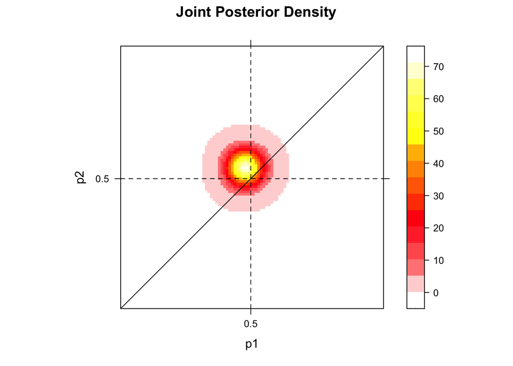

```r
ar_data = data[data$tosser=="ar", ]
ar_ball1 = ar_data$ball_1
ar_ball2 = ar_data$ball_2
arWater_1 = sum(ar_ball1)
arWater_2 = sum(ar_ball2)
ar_n1 = length(ar_ball1)
ar_n2 = length(ar_ball2)

#Heat Map
priorM = computeJointPrior()
postM = computeJointPosterior(arWater_1, arWater_2, ar_n1, ar_n2, priorM)
library(lattice)
new.palette=colorRampPalette(c("white","red","yellow","white"),space="rgb")
levelplot(main= "Joint Posterior Density",
          postM, col.regions=new.palette(20),
          xlab = "p1", ylab = "p2",
          scales=list(x=list(at=c(50), labels=c(0.5)),
                      y=list(at=c(50), labels=c(0.5))),
          panel = function(...){
            panel.levelplot(...)
            panel.abline(0,1, col = "black")
            panel.abline(v=50, col = "black", lty=2)
            panel.abline(h=50, col = "black", lty=2)})
```

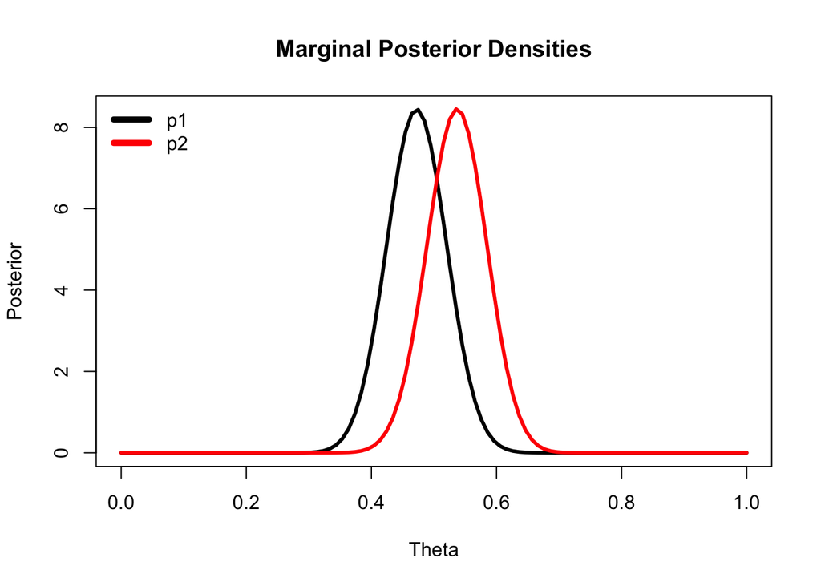

```r
#Marginal Posterior
computePost <- function(data, prior) {
  success = sum(data)
  trials = length(data)
  likelyhood = dbinom(x = success, size = trials, prob = pGrid)
  posterior = likelyhood * prior
  return(posterior / (sum(posterior) * gridSize))
}
prior = dbeta(x = pGrid, shape1 = aPrior, shape2 = bPrior)
post_ball1 = computePost(ar_ball1, prior)
post_ball2 = computePost(ar_ball2, prior)
plot(main = "Marginal Posterior Densities", pGrid, post_ball1,
     type = "l", lwd = 3, xlab = "Theta", ylab = "Posterior")
lines(pGrid, post_ball2, type = "l", lwd = 3, col = "red")
legend("topleft", legend = c("p1", "p2"), lty = 1,
       col = c("black", "red"), lwd = c(5, 5), bty = "n")
```

```r
#Mean and Standard Deviation and Posterior Probability that p1 < p2
posterior_mean_ball1 = sum(pGrid * post_ball1) * gridSize
posterior_sd_ball1 =
  sqrt(sum((pGrid - posterior_mean_ball1)^2 * post_ball1) * gridSize)
posterior_mean_ball2 = sum(pGrid * post_ball2) * gridSize
posterior_sd_ball2 =
  sqrt(sum((pGrid - posterior_mean_ball2)^2 * post_ball2) * gridSize)
cat("\nMean for ball 1 posterior: ", round(posterior_mean_ball1, 5))
```

```
##
## Mean for ball 1 posterior:  0.47273
```

```r
cat("\nSD for ball 1 posterior: ", round(posterior_sd_ball1, 5))
```

```
##
## SD for ball 1 posterior:  0.04739
```

```r
cat("\nMean for ball 2 posterior: ", round(posterior_mean_ball2, 5))
```

```
##
## Mean for ball 2 posterior:  0.53636
```

```r
cat("\nSD for ball 2 posterior: ", round(posterior_sd_ball2, 5))
```

```
##
## SD for ball 2 posterior:  0.04733
```

```r
prob = sum(postM[upper.tri(postM, TRUE)]) * (gridSize ^ 2)
cat("\nPosterior Probability that p1 < p2: ", prob)
```

```
##
## Posterior Probability that p1 < p2:  0.8471127
```

# step 2: Fit only using new data

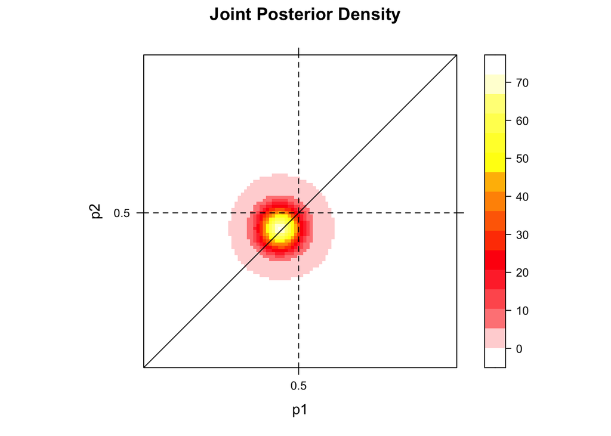

```r
nh_data = data[data$tosser=="nh", ]
nh_ball1 = nh_data$ball_1
nh_ball2 = nh_data$ball_2
nhWater_1 = sum(nh_ball1)
nhWater_2 = sum(nh_ball2)
nh_n1 = length(nh_ball1)
nh_n2 = length(nh_ball2)

#Heat Map
priorM = computeJointPrior()
postM = computeJointPosterior(nhWater_1, nhWater_2, nh_n1, nh_n2, priorM)
library(lattice)
new.palette=colorRampPalette(c("white","red","yellow","white"),space="rgb")
levelplot(main= "Joint Posterior Density",
          postM, col.regions=new.palette(20),
          xlab = "p1", ylab = "p2",
          scales=list(x=list(at=c(50), labels=c(0.5)),
                      y=list(at=c(50), labels=c(0.5))),
          panel = function(...){
            panel.levelplot(...)
            panel.abline(0,1, col = "black")
            panel.abline(v=50, col = "black", lty=2)
            panel.abline(h=50, col = "black", lty=2)})
```

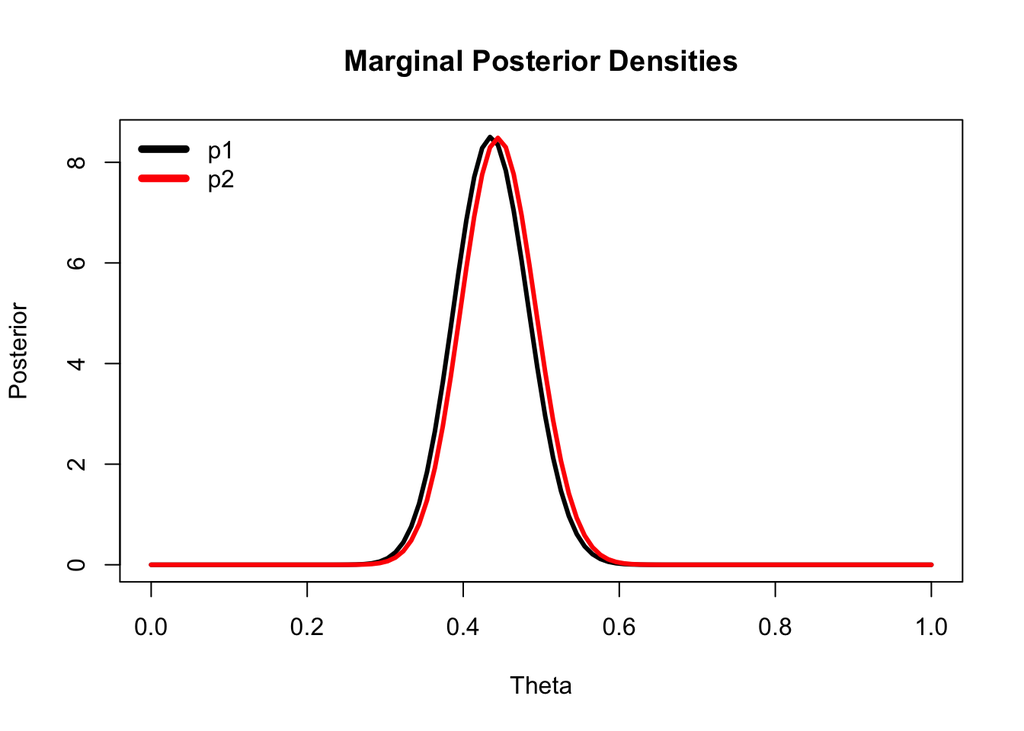

```r
#Marginal Posterior
prior = dbeta(x = pGrid, shape1 = aPrior, shape2 = bPrior)
post_ball1 = computePost(nh_ball1, prior)
post_ball2 = computePost(nh_ball2, prior)
plot(main = "Marginal Posterior Densities", pGrid, post_ball1,
     type = "l", lwd = 3, xlab = "Theta", ylab = "Posterior")
lines(pGrid, post_ball2, type = "l", lwd = 3, col = "red")
legend("topleft", legend = c("p1", "p2"), lty = 1,
       col = c("black", "red"), lwd = c(5, 5), bty = "n")
```

```r
#Mean and Standard Deviation and Posterior Probability that p1 < p2
posterior_mean_ball1 = sum(pGrid * post_ball1) * gridSize
posterior_sd_ball1 =
  sqrt(sum((pGrid - posterior_mean_ball1)^2 * post_ball1) * gridSize)
posterior_mean_ball2 = sum(pGrid * post_ball2) * gridSize
posterior_sd_ball2 =
  sqrt(sum((pGrid - posterior_mean_ball2)^2 * post_ball2) * gridSize)
cat("\nMean for ball 1 posterior: ", round(posterior_mean_ball1, 5))
```

```
##
## Mean for ball 1 posterior:  0.43636
```

```r
cat("\nSD for ball 1 posterior: ", round(posterior_sd_ball1, 5))
```

```
##
## SD for ball 1 posterior:  0.04707
```

```r
cat("\nMean for ball 2 posterior: ", round(posterior_mean_ball2, 5))
```

```
##
## Mean for ball 2 posterior:  0.44545
```

```r
cat("\nSD for ball 2 posterior: ", round(posterior_sd_ball2, 5))
```

```
##
## SD for ball 2 posterior:  0.04717
```

```r
prob = sum(postM[upper.tri(postM, TRUE)]) * (gridSize ^ 2)
cat("\nPosterior Probability that p1 < p2: ", prob)
```

```
##
## Posterior Probability that p1 < p2:  0.583993
```

# Step 3: Fit using all the data

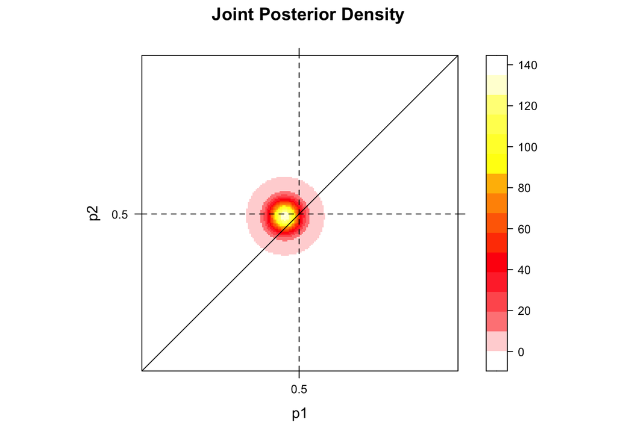

```r
ball1 = data$ball_1
ball2 = data$ball_2
success_ball1 = sum(ball1)
success_ball2 = sum(ball2)
n_ball1 = length(ball1)
n_ball2 = length(ball2)

nGridPoints = 200
pGrid = seq(from = 0, to = 1, length.out = nGridPoints)
gridSize = 1 / nGridPoints
#Heat Map
priorM = computeJointPrior()
postM = computeJointPosterior(success_ball1, success_ball2, n_ball1, n_ball2, priorM)
library(lattice)
new.palette=colorRampPalette(c("white","red","yellow","white"),space="rgb")
levelplot(main= "Joint Posterior Density",
          postM, col.regions=new.palette(20),
          xlab = "p1", ylab = "p2",
          scales=list(x=list(at=c(100), labels=c(0.5)),
                      y=list(at=c(100), labels=c(0.5))),
          panel = function(...){
            panel.levelplot(...)
            panel.abline(0,1, col = "black")
            panel.abline(v=100, col = "black", lty=2)
            panel.abline(h=100, col = "black", lty=2)})
```

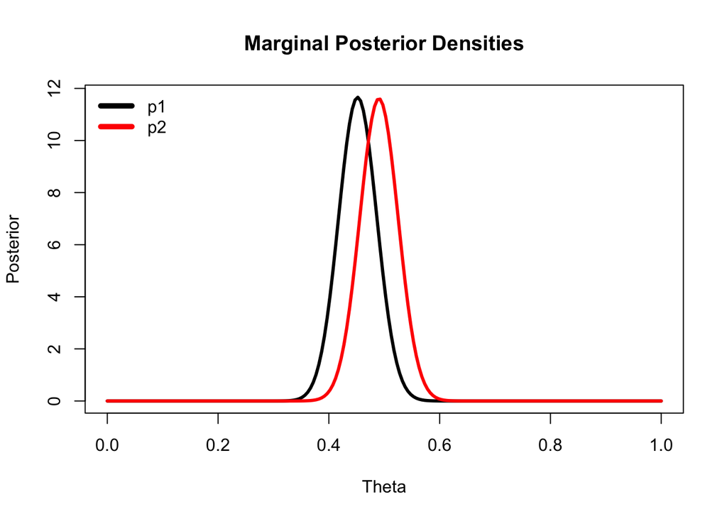

```r
prior = dbeta(x = pGrid, shape1 = aPrior, shape2 = bPrior)
post_ball1 = computePost(ball1, prior)
post_ball2 = computePost(ball2, prior)
plot(main = "Marginal Posterior Densities", pGrid, post_ball1,
     type = "l", lwd = 3, xlab = "Theta", ylab = "Posterior")
lines(pGrid, post_ball2, type = "l", lwd = 3, col = "red")
legend("topleft", legend = c("p1", "p2"), lty = 1,
       col = c("black", "red"), lwd = c(5, 5), bty = "n")
```

```r
#Mean and Standard Deviation and Posterior Probability that p1 < p2
posterior_mean_ball1 = sum(pGrid * post_ball1) * gridSize
posterior_sd_ball1 =
  sqrt(sum((pGrid - posterior_mean_ball1)^2 * post_ball1) * gridSize)
posterior_mean_ball2 = sum(pGrid * post_ball2) * gridSize
posterior_sd_ball2 =
  sqrt(sum((pGrid - posterior_mean_ball2)^2 * post_ball2) * gridSize)
cat("\nMean for ball 1 posterior: ", round(posterior_mean_ball1, 5))
```

```
##
## Mean for ball 1 posterior:  0.45238
```

```r
cat("\nSD for ball 1 posterior: ", round(posterior_sd_ball1, 5))
```

```
##
## SD for ball 1 posterior:  0.03426
```

```r
cat("\nMean for ball 2 posterior: ", round(posterior_mean_ball2, 5))
```

```
##
## Mean for ball 2 posterior:  0.49048
```

```r
cat("\nSD for ball 1 posterior: ", round(posterior_sd_ball2, 5))
```

```
##
## SD for ball 1 posterior:  0.03442
```

```r
prob = sum(postM[upper.tri(postM, TRUE)]) * (gridSize ^ 2)
cat("\nPosterior Probability that p1 < p2: ", prob)
```

```
##
## Posterior Probability that p1 < p2:  0.7983631
```

# PART 2

# step 1

### Methods

```r
n = 100
bivariate <-function(p1, p2, mu1, mu2, var1, var2, p) {
  N = 1 / (2 * pi * var1 * var2 * sqrt(1 - p^2))
  z1 = ((p1 - mu1) ^ 2) / (var1 ^ 2)
  z2 = (2 * p * (p1 - mu1) * (p2 - mu2)) / (var1 * var2)
  z3 = ((p2 - mu2) ^ 2) / (var2 ^ 2)
  Z = z1 -z2 + z3
  joint_pdf = N * exp((-1 / (2 * (1 - p^2))) * Z)
  return(joint_pdf)
}
bivariate_PriorM <- function(mu1, mu2, var1, var2, p) {
  pGrid = seq(from = 0, to = 1, length.out = n)
  priorM = matrix(rep(1, n ^ 2),
                  nrow = n,
                  ncol = n,
                  byrow = TRUE)
  for (row in 1:n) {
    for (col in 1:n) {
      p1 = pGrid[row]
      p2 = pGrid[col]
      priorM[row, col] = bivariate(p1, p2, mu1, mu2, var1, var2, p)
    }
  }
  return(priorM / (sum(priorM) * (1 / n) ^ 2)) # To normalize
}
```

### A

```r
mu1 = mu2 = 0.5
var1 = var2 = 1
p = 0
priorM = bivariate_PriorM(mu1, mu2, var1, var2, p)
cat("Sum of Prior: ", sum(priorM * (1 / n) ^ 2))
```

```
## Sum of Prior:  1
```

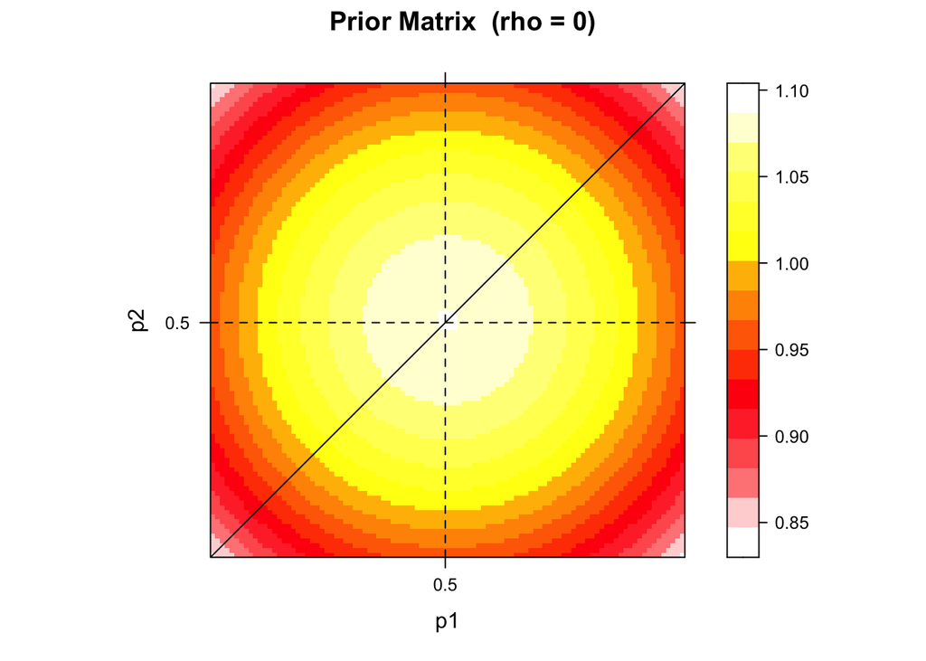

```r
levelplot(main= "Prior Matrix  (rho = 0)",
          priorM, col.regions=new.palette(20),
          xlab = "p1", ylab = "p2",
          scales=list(x=list(at=c(50), labels=c(0.5)),
                      y=list(at=c(50), labels=c(0.5))),
          panel = function(...){
            panel.levelplot(...)
            panel.abline(0,1, col = "black")
            panel.abline(v=50, col = "black", lty=2)
            panel.abline(h=50, col = "black", lty=2)})
```

### B

```r
mu1 = mu2 = 0.5
var1 = var2 = 1
p = 0.25
priorM = bivariate_PriorM(mu1, mu2, var1, var2, p)
cat("Sum of Prior: ", sum(priorM * (1 / n) ^ 2))
```

```
## Sum of Prior:  1
```

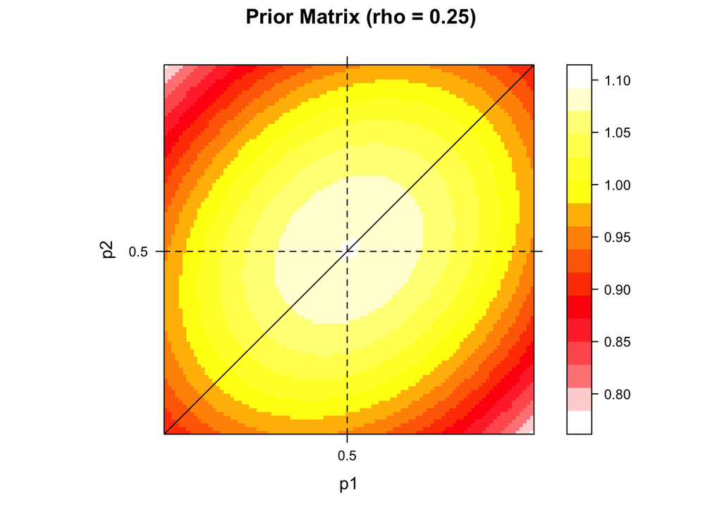

```r
levelplot(main= "Prior Matrix (rho = 0.25)",
          priorM, col.regions=new.palette(20),
          xlab = "p1", ylab = "p2",
          scales=list(x=list(at=c(50), labels=c(0.5)),
                      y=list(at=c(50), labels=c(0.5))),
          panel = function(...){
            panel.levelplot(...)
            panel.abline(0,1, col = "black")
            panel.abline(v=50, col = "black", lty=2)
            panel.abline(h=50, col = "black", lty=2)})
```

### C

```r
mu1 = mu2 = 0.5
var1 = var2 = 1
p = 0.5
priorM = bivariate_PriorM(mu1, mu2, var1, var2, p)
cat("Sum of Prior: ", sum(priorM * (1 / n) ^ 2))
```

```
## Sum of Prior:  1
```

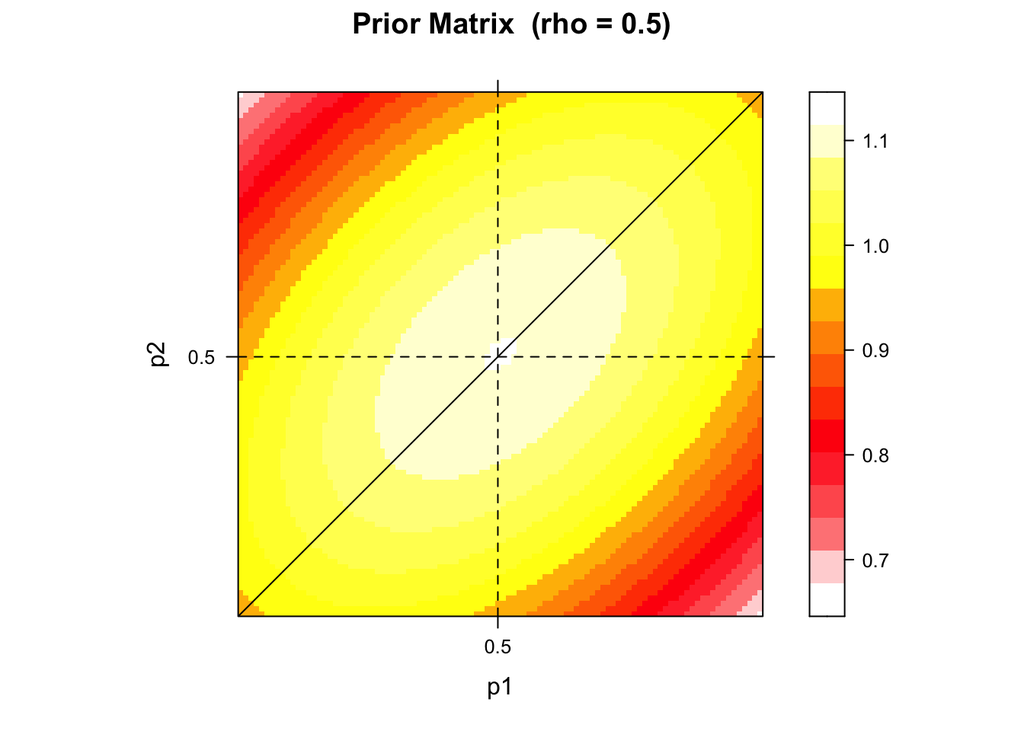

```r
levelplot(main= "Prior Matrix  (rho = 0.5)",
          priorM, col.regions=new.palette(20),
          xlab = "p1", ylab = "p2",
          scales=list(x=list(at=c(50), labels=c(0.5)),
                      y=list(at=c(50), labels=c(0.5))),
          panel = function(...){
            panel.levelplot(...)
            panel.abline(0,1, col = "black")
            panel.abline(v=50, col = "black", lty=2)
            panel.abline(h=50, col = "black", lty=2)})
```

## Step 2

## A

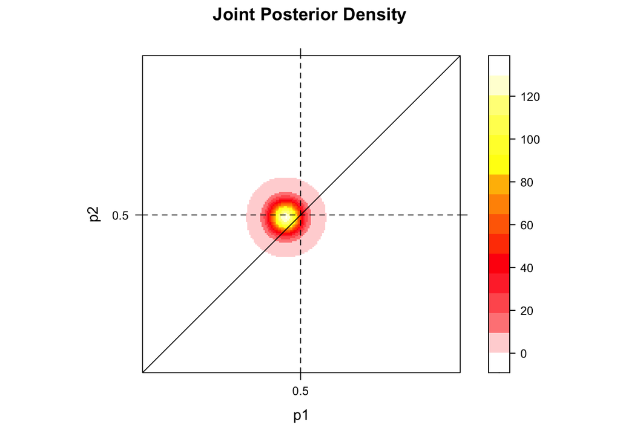

```r
n = 200
nGridPoints = 200
pGrid = seq(from = 0, to = 1, length.out = nGridPoints)
gridSize = 1 / nGridPoints
mu1 = mu2 = 0.5
var1 = var2 = 1
p = 0

priorM = bivariate_PriorM(mu1, mu2, var1, var2, p)
postM = computeJointPosterior(success_ball1, success_ball2, n_ball1, n_ball2, priorM)
levelplot(main= "Joint Posterior Density",
          postM, col.regions=new.palette(20),
          xlab = "p1", ylab = "p2",
          scales=list(x=list(at=c(100), labels=c(0.5)),
                      y=list(at=c(100), labels=c(0.5))),
          panel = function(...){
            panel.levelplot(...)
            panel.abline(0,1, col = "black")
            panel.abline(v=100, col = "black", lty=2)
            panel.abline(h=100, col = "black", lty=2)})
```

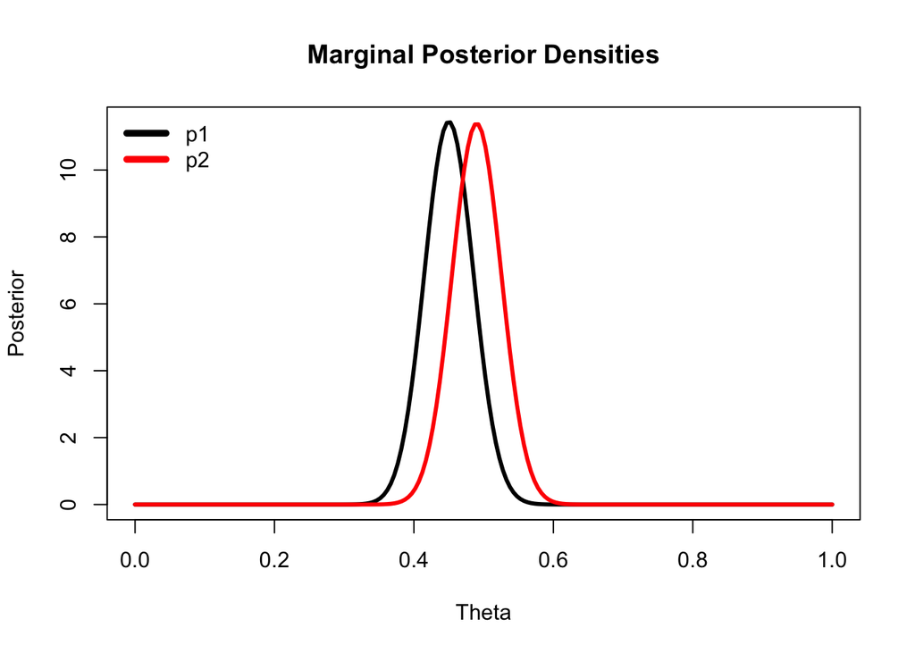

```r
post_ball1 = computePost(ball1, rowSums(priorM))
post_ball2 = computePost(ball2, colSums(priorM))
plot(main = "Marginal Posterior Densities", pGrid, post_ball1,
     type = "l", lwd = 3, xlab = "Theta", ylab = "Posterior")
lines(pGrid, post_ball2, type = "l", lwd = 3, col = "red")
legend("topleft", legend = c("p1", "p2"), lty = 1,
       col = c("black", "red"), lwd = c(5, 5), bty = "n")
```

```r
#Mean and Standard Deviation and Posterior Probability that p1 < p2
posterior_mean_ball1 = sum(pGrid * post_ball1) * gridSize
posterior_sd_ball1 =
  sqrt(sum((pGrid - posterior_mean_ball1)^2 * post_ball1) * gridSize)
posterior_mean_ball2 = sum(pGrid * post_ball2) * gridSize
posterior_sd_ball2 =
  sqrt(sum((pGrid - posterior_mean_ball2)^2 * post_ball2) * gridSize)
cat("\nMean for ball 1 posterior: ", round(posterior_mean_ball1, 5))
```

```
##
## Mean for ball 1 posterior:  0.45055
```

```r
cat("\nSD for ball 1 posterior: ", round(posterior_sd_ball1, 5))
```

```
##
## SD for ball 1 posterior:  0.0349
```

```r
cat("\nMean for ball 2 posterior: ", round(posterior_mean_ball2, 5))
```

```
##
## Mean for ball 2 posterior:  0.49011
```

```r
cat("\nSD for ball 1 posterior: ", round(posterior_sd_ball2, 5))
```

```
##
## SD for ball 1 posterior:  0.03507
```

```r
prob = sum(postM[upper.tri(postM, TRUE)]) * (gridSize ^ 2)
cat("\nPosterior Probability that p1 < p2: ", prob)
```

```
##
## Posterior Probability that p1 < p2:  0.8023078
```

### B

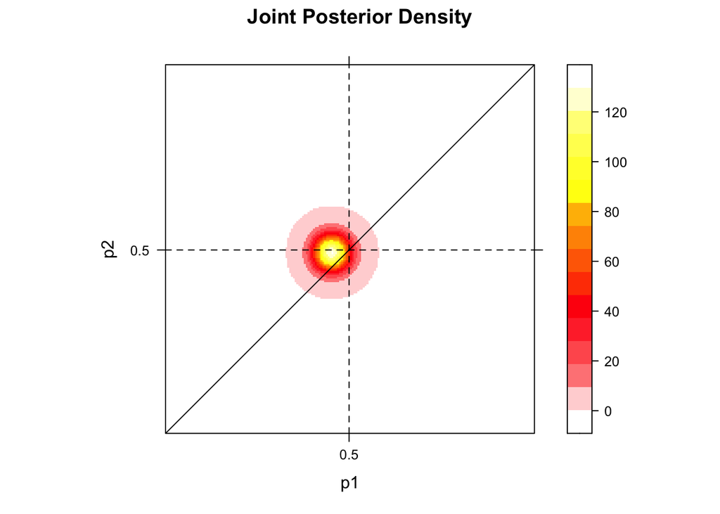

```r
n = 200
nGridPoints = 200
pGrid = seq(from = 0, to = 1, length.out = nGridPoints)
gridSize = 1 / nGridPoints
mu1 = mu2 = 0.5
var1 = var2 = 1
p = 0.25

priorM = bivariate_PriorM(mu1, mu2, var1, var2, p)
postM = computeJointPosterior(success_ball1, success_ball2, n_ball1, n_ball2, priorM)
levelplot(main= "Joint Posterior Density",
          postM, col.regions=new.palette(20),
          xlab = "p1", ylab = "p2",
          scales=list(x=list(at=c(100), labels=c(0.5)),
                      y=list(at=c(100), labels=c(0.5))),
          panel = function(...){
            panel.levelplot(...)
            panel.abline(0,1, col = "black")
            panel.abline(v=100, col = "black", lty=2)
            panel.abline(h=100, col = "black", lty=2)})
```

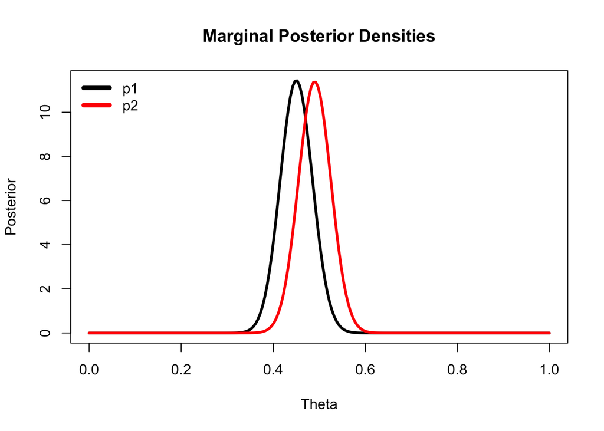

```r
post_ball1 = computePost(ball1, rowSums(priorM))
post_ball2 = computePost(ball2, colSums(priorM))
plot(main = "Marginal Posterior Densities", pGrid, post_ball1,
     type = "l", lwd = 3, xlab = "Theta", ylab = "Posterior")
lines(pGrid, post_ball2, type = "l", lwd = 3, col = "red")
legend("topleft", legend = c("p1", "p2"), lty = 1,
       col = c("black", "red"), lwd = c(5, 5), bty = "n")
```

```r
#Mean and Standard Deviation and Posterior Probability that p1 < p2
posterior_mean_ball1 = sum(pGrid * post_ball1) * gridSize
posterior_sd_ball1 =
  sqrt(sum((pGrid - posterior_mean_ball1)^2 * post_ball1) * gridSize)
posterior_mean_ball2 = sum(pGrid * post_ball2) * gridSize
posterior_sd_ball2 =
  sqrt(sum((pGrid - posterior_mean_ball2)^2 * post_ball2) * gridSize)
cat("\nMean for ball 1 posterior: ", round(posterior_mean_ball1, 5))
```

```
##
## Mean for ball 1 posterior:  0.45056
```

```r
cat("\nSD for ball 1 posterior: ", round(posterior_sd_ball1, 5))
```

```
##
## SD for ball 1 posterior:  0.0349
```

```r
cat("\nMean for ball 2 posterior: ", round(posterior_mean_ball2, 5))
```

```
##
## Mean for ball 2 posterior:  0.49011
```

```r
cat("\nSD for ball 1 posterior: ", round(posterior_sd_ball2, 5))
```

```
##
## SD for ball 1 posterior:  0.03506
```

```r
prob = sum(postM[upper.tri(postM, TRUE)]) * (gridSize ^ 2)
cat("\nPosterior Probability that p1 < p2: ", prob)
```

```
##
## Posterior Probability that p1 < p2:  0.8022654
```

### C

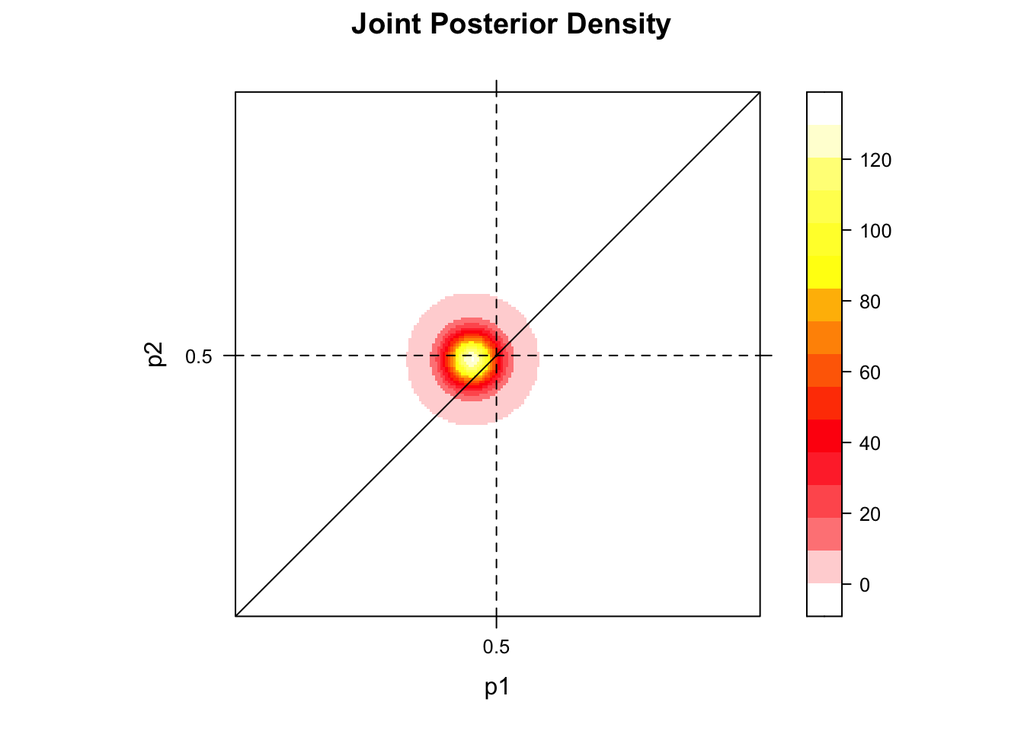

```r
n = 200
nGridPoints = 200
pGrid = seq(from = 0, to = 1, length.out = nGridPoints)
gridSize = 1 / nGridPoints
mu1 = mu2 = 0.5
var1 = var2 = 1
p = 0.5

priorM = bivariate_PriorM(mu1, mu2, var1, var2, p)
postM = computeJointPosterior(success_ball1, success_ball2, n_ball1, n_ball2, priorM)
levelplot(main= "Joint Posterior Density",
          postM, col.regions=new.palette(20),
          xlab = "p1", ylab = "p2",
          scales=list(x=list(at=c(100), labels=c(0.5)),
                      y=list(at=c(100), labels=c(0.5))),
          panel = function(...){
            panel.levelplot(...)
            panel.abline(0,1, col = "black")
            panel.abline(v=100, col = "black", lty=2)
            panel.abline(h=100, col = "black", lty=2)})
```

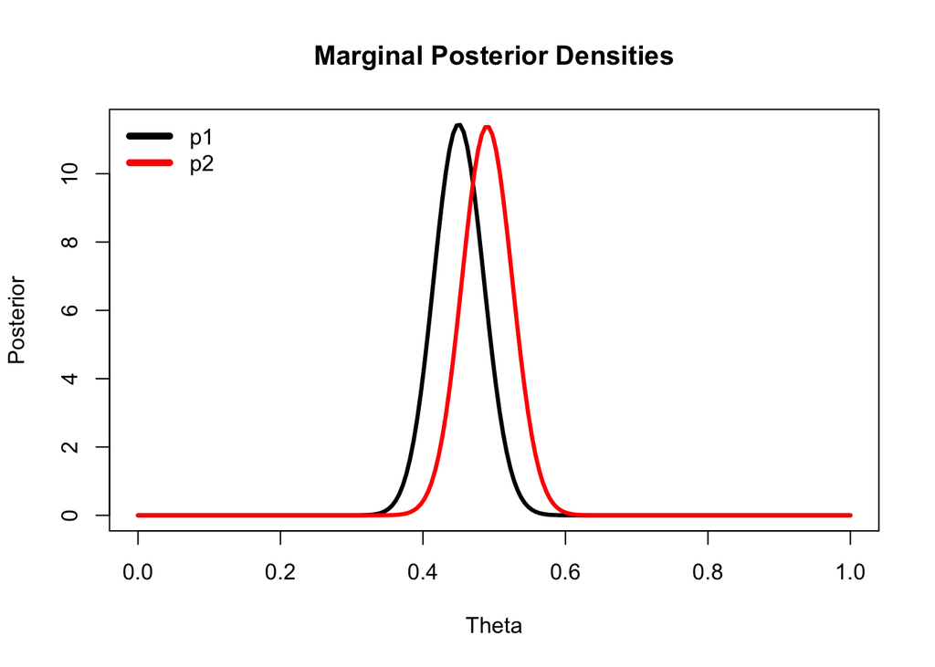

```r
post_ball1 = computePost(ball1, rowSums(priorM))
post_ball2 = computePost(ball2, colSums(priorM))
plot(main = "Marginal Posterior Densities", pGrid, post_ball1,
     type = "l", lwd = 3, xlab = "Theta", ylab = "Posterior")
lines(pGrid, post_ball2, type = "l", lwd = 3, col = "red")
legend("topleft", legend = c("p1", "p2"), lty = 1,
       col = c("black", "red"), lwd = c(5, 5), bty = "n")
```

```r
#Mean and Standard Deviation and Posterior Probability that p1 < p2
posterior_mean_ball1 = sum(pGrid * post_ball1) * gridSize
posterior_sd_ball1 =
  sqrt(sum((pGrid - posterior_mean_ball1)^2 * post_ball1) * gridSize)
posterior_mean_ball2 = sum(pGrid * post_ball2) * gridSize
posterior_sd_ball2 =
  sqrt(sum((pGrid - posterior_mean_ball2)^2 * post_ball2) * gridSize)
cat("\nMean for ball 1 posterior: ", round(posterior_mean_ball1, 5))
```

```
##
## Mean for ball 1 posterior:  0.45057
```

```r
cat("\nSD for ball 1 posterior: ", round(posterior_sd_ball1, 5))
```

```
##
## SD for ball 1 posterior:  0.03489
```

```r
cat("\nMean for ball 2 posterior: ", round(posterior_mean_ball2, 5))
```

```
##
## Mean for ball 2 posterior:  0.49011
```

```r
cat("\nSD for ball 1 posterior: ", round(posterior_sd_ball2, 5))
```

```
##
## SD for ball 1 posterior:  0.03506
```

```r
prob = sum(postM[upper.tri(postM, TRUE)]) * (gridSize ^ 2)
cat("\nPosterior Probability that p1 < p2: ", prob)
```

```
##
## Posterior Probability that p1 < p2:  0.8021807
```

## Step 3

Rho depicts the correlation between our priors and as we scale it up and down, there is no noticeable changes in our posterior plots as seen above where our means and standard deviation are extremely close as we scale rho. Because our data set is large, our posteriors are mostly driven by the data.

# PART 3

## Step 1

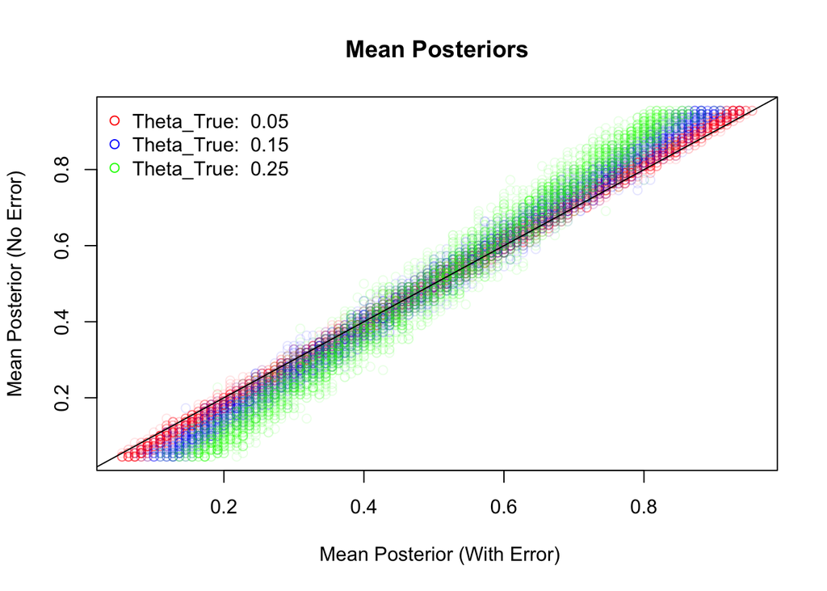

```r
set.seed(123)

#params
sim = 10000
tosses = 100
thetas = rep(0, sim)
mean_post_error = rep(0, sim)
mean_post_no_error = rep(0, sim)

#grid points
nGridPoints = 100
gridSize = 1 / nGridPoints
pGrid = seq(from = 0, to = 1, length.out = nGridPoints)
prior = dbeta(pGrid, aPrior, bPrior)

#simulation
for (i in 1:sim) {
  pTrue = runif(1, min=0, max=1)
  thetaTrue = sample(c(0.05, 0.15, 0.25), 1)
  dataNoError = rbinom(tosses, 1, pTrue)
  sus_tosses = tosses * thetaTrue
  to_replace = sample(1:100, sus_tosses)
  dataWithError = dataNoError
  dataWithError[to_replace] = rbinom(sus_tosses, 1, 0.5)

  thetas[i] = thetaTrue
  post_error = computePost(dataWithError, prior)
  post_no_error = computePost(dataNoError, prior)
  mean_post_error[i] = sum(post_error * pGrid) * gridSize
  mean_post_no_error[i] = sum(post_no_error * pGrid) * gridSize
}
theta_1 = which(thetas == 0.05)
theta_2 = which(thetas == 0.15)
theta_3 = which(thetas == 0.25)
plot(main = "Mean Posteriors",
     mean_post_error[theta_1], mean_post_no_error[theta_1],
     ylab = "Mean Posterior (No Error)", xlab = " Mean Posterior (With Error)",
     col=rgb(1, 0, 0, alpha = 0.1)
     )
points(mean_post_error[theta_2], mean_post_no_error[theta_2], col=rgb(0, 0, 1, alpha = 0.1))
points(mean_post_error[theta_3], mean_post_no_error[theta_3], col=rgb(0, 1, 0, alpha = 0.1))
abline(0,1, col="black")
legend("topleft", legend=c(paste("Theta_True: ", 0.05),
                           paste("Theta_True: ", 0.15),
                           paste("Theta_True: ", 0.25)), bty="n",
                           pch=c(1, 1, 1), col=c(rgb(1, 0, 0), rgb(0, 0, 1), rgb(0, 1, 0)))
```

## Step 2

The black line represents values where the mean posterior with and without error are equal. We see that for lower theta values, the mean posteriors have a slope very close to the black line. However, as theta increases, we see that the mean rotates to the left around the the point (0.5, 0.5), the true mean of our 100 coin flip until it become vertical at theta = 1. This makes sense as when theta equals 1 then we assume all of our data has measurement error meaning we flip the coin 100 times for each simulation leading to a mean (with error) of 0.5 hence the vertical line at x = 0.5. The reason we see this rotation is because as we increase theta, we increase the number of measurements with error that we are accounting for therefore leading the mean towards the true mean of a coin flip (vertical line at x = 0.5).